# Marine Ecological Modelling Global Climate Change

Jorge Assis, PhD // Centre of Marine Sciences, University of Algarve

## Biodiversity data

## Biodiversity data

Ecological niche models require georeferenced biodiversity occurrence data (e.g. species locations, which is the response or dependent variable). Such information are widely available in digital format (e.g., online repositories provide data on species distributions like GBIF).

```r
# read records
records <- read.table('Data/dataBases/MergedCoordinates.csv',sep=';',header=TRUE)

# read a landmass polygon
world <- shapefile("Data/vectorShapefiles/globalLandmass/world.shp")

# crop landmass to the european Extent
europeanExtent <- extent(-35, 45, 25, 55)
landmassEur <- crop(world, europeanExtent)
```

S3 // Biodiversity data in R

## Plot biodiversity occurrence data with R.

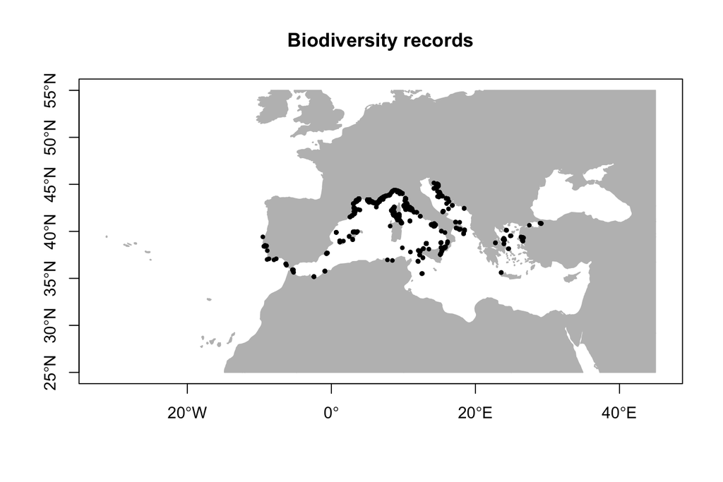

```r
# plot the landmass and the records
plot(landmassEur, main="Biodiversity records", col='Gray', border='Gray', axes=TRUE)
points( records, col="Black" , pch= 19, cex=0.5)
```

S3 // Biodiversity data in R

### Challenge 3.1

The main objective of this challenge is to **plot** biodiversity records **from a file**, for a given **region**.

**Packages, data and functions to accomplish the challenge:**

Go to Menu -> Sessions -> Set the working directory -> My directory of Sessions_[P]  
Do: source(“sourceFunctions.R”)  
Files to use:  
"your_own_file.csv"  
"Data/vectorShapefiles/globalLandmass/world.shp"  
Functions:  
library(raster)  
shapefile(path)  
extent(object)  
crop(object)  
read.table(path)  
plot(object)  
points(object)

S3 // Biodiversity data in R

## Data cleaning in R

Data ‘cleaning’ is particularly important for data sourced from data warehouses such as GBIF.

### Remove NA coordinates

```r
# get data from GBIF
records <- read.table('Data/dataBases/MergedCoordinates.csv', sep=';', header=TRUE)

# remove NA coordinates; Give the proper Longitude and Latitude column names
records <- removeNA(records, "Lon", "Lat")
```

```
## Removing 0 NA records
```

S3 // Biodiversity data in R

### Remove duplicate coordinates

```r
# remove duplicate coordinates; Give the proper Longitude and Latitude column names
records <- removeDuplicated(records, "Lon", "Lat")
```

```
## Removing 4211 duplicated records
```

S3 // Biodiversity data in R

### Remove records outside known distributions

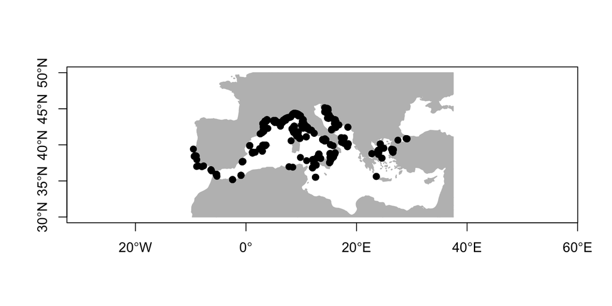

```r
# open a landmass file and the records
landmass <- shapefile("Data/vectorShapefiles/globalLandmass/world.shp")
records <- read.table('Data/dataBases/MergedCoordinates.csv',sep=';',header=TRUE)

# crop landmass file and make plot
mediterraneanExtent <- extent(-15, 37.5, 30, 50)
landmassEur <- crop(landmass, mediterraneanExtent)
plot(landmassEur, col='Gray', border='Gray', axes=TRUE)
points( records, col="Black" , pch= 19)
```

S3 // Biodiversity data in R

Remove records outside known latitudinal and longitudinal distribution

- plot a polygon defining the region of interest;
- use function drawPoly() to choose the region where the species occur (press Esc. to exit);
- use function whichOverPolygon() to select the records within the drawn polygon.

```r
# plot a polygon defining the region of interest
plot(landmassEur)
points( records, col="Black" , pch= 19)

# choose the region where the species occur
regionOfInterest <- drawPoly()

# select the records within the drawn polygon
pointsInRegion <- whichOverPolygon(records,regionOfInterest)

# clip the records of occurrence
records <- records[pointsInRegion,]
```

S3 // Biodiversity data in R

### Challenge 3.2

The objetive of this challenge is to **clean records** for a species that only occurs in the Mediterranean, and produce a **plot**.

**Packages, data and functions to accomplish the challenge:**

Go to Menu -> Sessions -> Set the working directory -> My directory of Sessions_[P]  
Run: source(“sourceFunctions.R”)  
Files to use:  
"Data/dataBases/MergedCoordinates.csv"  
"Data/vectorShapefiles/globalLandmass/world.shp"  
Functions and libraries to use:  
library(raster)  
shapefile(path)  
extent(object) & crop(object)  
read.table(path)  
whichOverPolygon(object)  
drawPoly(object)  
plot(object) & points(object)

S3 // Biodiversity data in R

## References

Global change impacts on biodiversity. Available at: https://damariszurell.github.io/HU-GCIB

Copyright (c) Earth Lab. Available at: https://www.earthdatascience.org.

Open Science for Synthesis: Gulf Research Program Workshop. Available at: https://github.com/NCEAS/oss-lessons

Gimond, M. (2019) Intro to GIS and Spatial Analysis. Available at: https://mgimond.github.io/Spatial/